# starter_pack_el_salvador

# 1 Starter Pack: Drought risk in El Salvador

This contains the code and documentation for a drought risk analysis for El Salvador. The notebooks explore impacts on maize, beans and sorghum.

## 1.1 Setup

- Clone this repository to your local machine, or download a ZIP of this folder by clicking the green ‘Code’ dropdown above followed by the ‘Download ZIP’ button.
- Set up a virtual environment with CLIMADA installed. The CLIMADA [Getting Started](https://climada-python.readthedocs.io/en/stable/getting-started/index.html) guide explains how.
- If necessary, set up Jupyter notebooks. You can look up how do this at a system level, which allows the functionality to be reused across environments, or on the command line you can activate your virtual environment (covered in the guide linked above) and run `mamba install jupyter` (you can replace `mamba` with `conda` or with the relevant installation instruction for your environment manager.)
- Either: Open the folder in your preferred development environment and activate the virtual environment. OR: from the command line activate your virtual environment (covered in the guide linked above) and run `jupyter notebook`.
- Run these notebooks. You may need to edit the filepaths at the start of each file. Throughout the notebooks parameters can be changed, and datasets can be modified and improved. We encourage you to explore.

## 1.2 Structure

- The data/ folder contains all the required input data
- The notebooks/ folder goes through the risk analysis step by step:
  - 01_entity_exposures.ipynb – Mapping the exposed assets
  - 02_entity_impact_functions.ipynb – Visualising the impact functions
  - 03_hazard.ipynb – Mapping the hazard data
  - 04_uncalibrated_risk.ipynb – Running a risk calculation with the uncalibrated data
  - 05_observations.ipynb - Preparing observational data
  - 06a_calibration_maize.ipynb - Calibrating the risk calculation for maize
  - 07_future_risk.ipynb - Adding future hazard and exposure data and quantifying the change in risk
- The starter_pack_el_salvador.html file contains these notebooks and their output in a single HTML file

## 1.3 Contributing

This analysis is intended to support teaching materials and is still under development. If any of the code doesn’t work, if something could be added to improve the analysis, or if something could be explained more clearly, please let us know. You can do this by creating a GitHub Issue, or by contacting us by email.

# 2 Exposed assets

In this notebook we read Entity files for El Salvador and visualize the Exposures data for maize, beans and sorghum.

## 2.1 Read Exposures from Entity files

The `climada.entity` package provides the tools to interact with Entity files.

Exposure data must be stored in the *first sheet* of the Excel workbook, called ‘assets’ by convention. The exposure data is stored in the Entity’s `exposures` attribute, and is an instance of CLIMADA’s [Exposures](https://climada-python.readthedocs.io/en/v6.1.0/user-guide/climada_entity_Exposures.html) class. They don’t need to be financial: the units are specified within the file.

Let’s set up our project folders and read in the file(s). This notebook (and the following notebooks) is set up to explore a list of different Entity files, each containing a different asset type.

**NOTE:** You can also create Exposures objects from pandas DataFrames, geopandas GeoDataframes, other Excel files, CSVs, HDF5 files, and raster (e.g. TIF) data. See the [CLIMADA User Guide](https://climada-python.readthedocs.io/en/v6.1.0/user-guide/climada_entity_Exposures.html) for the different ways to do this.

```python
from pathlib import Path

# Set the directory where our Entity files are located
ENTITY_DIR = "../data/entity_files_uncalibrated/"
# Give a dictionary of Entity file names
ENTITY_FILES = {
    "maize": "El_Salvador_Entity_Drought_Maize.xlsx",
    "beans": "El_Salvador_Entity_Drought_Beans.xlsx",
    "sorghum": "El_Salvador_Entity_Drought_Sorghum.xlsx"
}
entity_filepaths = {crop: Path(ENTITY_DIR) / filename for crop, filename in ENTITY_FILES.items()}
```

```python
import copy
from climada.entity import Entity

# Read in the files
entity_dict = {}
for crop, filepath in entity_filepaths.items():
    print(f"Reading {filepath.name}...")
    entity = Entity.from_excel(filepath)

    # After reading in the file, it is a good idea to set additional properties of the Exposures object

    # ref_year:
    # We can optionally set a reference year for the entity, which describes the year (past, present or future) that the data represent.
    # This is required when the Exposures are used in a cost-benefit analysis, comparing risk at two different points in time.
    entity.exposures.ref_year = 2026

    # value_unit:
    # The unit of the exposure values. This needs to be specified but will be read from the Excel file after the next release
    entity.exposures.value_unit = "kg"

    # description:
    # Optional – used for creating plot titles
    entity.exposures.description = f"Annual {crop} production ({entity.exposures.value_unit})"

    entity_dict[crop] = copy.deepcopy(entity)


# We can then store the exposures in their own dictionary by accessing the `exposures` property:
exposures_dict = {crop: entity.exposures for crop, entity in entity_dict.items()}
```

```
Reading El_Salvador_Entity_Drought_Maize.xlsx...
Reading El_Salvador_Entity_Drought_Beans.xlsx...
Reading El_Salvador_Entity_Drought_Sorghum.xlsx...
```

## 2.2 Exposures properties

The Excel sheets we just read in are stored in the `Exposures.gdf` (=‘GeoDataFrame’) attribute. We can print some summary information about the Exposures we’re working with:

```python
from IPython.display import display

for crop, exp in exposures_dict.items():
    print("")
    print(crop.title())
    print(f"- The Exposures consists of {len(exp.gdf)} points")
    print(f"- Their total value is {exp.gdf['value'].sum():,.0f} {exp.value_unit}")
    print(f"- The points lie between latitudes {exp.gdf.geometry.y.min():.2f} and {exp.gdf.geometry.y.max():.2f}")
    print(f"- The points lie between longitudes {exp.gdf.geometry.x.min():.2f} and {exp.gdf.geometry.x.max():.2f}")
    # Note: newer versions of CLIMADA let you use the simpler exp.latitude and exp.longitude properties

    # If there is region information
    if "region_id" in exp.gdf.columns:
        print(f" -The exposure contains {exp.gdf['region_id'].nunique()} region id(s)")
    # If there is category information
    if "category_id" in exp.gdf.columns:
        print(f"- The exposure contains {exp.gdf['category_id'].nunique()} category id(s)")
    # Find information about impact functions – the column names for these depend on the hazard type
    for col in exp.gdf.columns:
        if col.startswith("impf_"):
            print(f"- The exposure uses {exp.gdf[col].nunique()} impact function(s) (column: '{col}')")

for crop, exp in exposures_dict.items():
    print('\n' + exp.description + ' (first 5 rows)')
    display(exp.gdf.head())
```

```
Maize
- The Exposures consists of 14 points
- Their total value is 788,391,516 kg
- The points lie between latitudes 13.38 and 14.13
- The points lie between longitudes -89.90 and -87.89
 -The exposure contains 1 region id(s)
- The exposure contains 1 category id(s)
- The exposure uses 1 impact function(s) (column: 'impf_DR')

Beans
- The Exposures consists of 14 points
- Their total value is 92,161,828 kg
- The points lie between latitudes 13.38 and 14.13
- The points lie between longitudes -89.90 and -87.89
 -The exposure contains 1 region id(s)
- The exposure contains 1 category id(s)
- The exposure uses 1 impact function(s) (column: 'impf_DR')

Sorghum
- The Exposures consists of 14 points
- Their total value is 107,811,764 kg
- The points lie between latitudes 13.38 and 14.13
- The points lie between longitudes -89.90 and -87.89
 -The exposure contains 1 region id(s)
- The exposure contains 1 category id(s)
- The exposure uses 1 impact function(s) (column: 'impf_DR')

Annual maize production (kg) (first 5 rows)
```

|  | category_id | region_id | value | Income (USD) | Production Area (ha) | Production (kg) | Yield (kg/ha) | deductible | cover | impf_DR | Value_unit | geometry |
| --- | --- | --- | --- | --- | --- | --- | --- | --- | --- | --- | --- | --- |
| 0 | 1 | 1 | 114614750 | 7.025272e+07 | 34227.9 | 114614750 | 3348.576746 | 0 | NaN | 101 | kg | POINT (-89.90196 13.85751) |
| 1 | 1 | 1 | 48487910 | 3.532011e+07 | 15638.7 | 48487910 | 3100.507715 | 0 | NaN | 101 | kg | POINT (-88.70886 13.87704) |
| 2 | 1 | 1 | 58267188 | 1.806401e+07 | 19657.4 | 58267188 | 2964.135033 | 0 | NaN | 101 | kg | POINT (-89.07457 14.13120) |
| 3 | 1 | 1 | 29470774 | 5.830404e+07 | 10362.8 | 29470774 | 2843.900683 | 0 | NaN | 101 | kg | POINT (-89.01998 13.83557) |
| 4 | 1 | 1 | 73225698 | 4.488344e+07 | 21501.2 | 73225698 | 3405.656335 | 0 | NaN | 101 | kg | POINT (-89.36268 13.70412) |

```
Annual beans production (kg) (first 5 rows)
```

|  | category_id | region_id | value | Income (USD) | Production Area (ha) | Production (kg) | Yield (kg/ha) | deductible | cover | impf_DR | Value_unit | geometry |
| --- | --- | --- | --- | --- | --- | --- | --- | --- | --- | --- | --- | --- |
| 0 | 1 | 1 | 15141590 | 2.711572e+07 | 13736.8 | 15141590 | 1102.264720 | 0 | NaN | 102 | kg | POINT (-89.90196 13.85751) |
| 1 | 1 | 1 | 10868926 | 1.036067e+07 | 9961.7 | 10868926 | 1091.071403 | 0 | NaN | 102 | kg | POINT (-88.70886 13.87704) |
| 2 | 1 | 1 | 10631382 | 5.157147e+06 | 10788.4 | 10631382 | 985.445664 | 0 | NaN | 102 | kg | POINT (-89.07457 14.13120) |
| 3 | 1 | 1 | 2879784 | 3.483686e+07 | 3124.8 | 2879784 | 921.589862 | 0 | NaN | 102 | kg | POINT (-89.01998 13.83557) |
| 4 | 1 | 1 | 8200006 | 1.468466e+07 | 8170.4 | 8200006 | 1003.623568 | 0 | NaN | 102 | kg | POINT (-89.36268 13.70412) |

```
Annual sorghum production (kg) (first 5 rows)
```

|  | category_id | region_id | value | Income (USD) | Production Area (ha) | Production (kg) | Yield (kg/ha) | deductible | cover | impf_DR | Value_unit | geometry |
| --- | --- | --- | --- | --- | --- | --- | --- | --- | --- | --- | --- | --- |
| 0 | 1 | 1 | 34511546 | 2.660003e+07 | 15552.6 | 34511546 | 2219.021000 | 0 | NaN | 103 | kg | POINT (-89.90196 13.85751) |
| 1 | 1 | 1 | 7064220 | 8.942066e+06 | 4271.4 | 7064220 | 1653.841832 | 0 | NaN | 103 | kg | POINT (-88.70886 13.87704) |
| 2 | 1 | 1 | 12708926 | 6.916212e+06 | 5569.2 | 12708926 | 2282.002083 | 0 | NaN | 103 | kg | POINT (-89.07457 14.13120) |
| 3 | 1 | 1 | 8973266 | 1.881553e+06 | 5607.0 | 8973266 | 1600.368468 | 0 | NaN | 103 | kg | POINT (-89.01998 13.83557) |
| 4 | 1 | 1 | 8939502 | 6.890188e+06 | 5159.0 | 8939502 | 1732.797441 | 0 | NaN | 103 | kg | POINT (-89.36268 13.70412) |

Points worth noting about the `Entity.exposures` geodataframe: - The original latitude and longitude columns have been converted to a ‘geometry’ column. You can still access the raw values with the `Exposures.latitude` and `Exposures.longitude` properties - The deductible and cover columns are used when asset-level insurance is modelled as an adaptation measure – for now they should be left blank in the Excel workbook - Each exposure point is acted on by an impact function. This is defined here in the ‘impf_DR’ column. The last two letters are used to specify the hazard type (here: drought) and is used in matching between datasets. A column ‘impf_’ with no hazard type is also valid, and will match to any hazard type.

## 2.3 Visualize the Exposures: points on a map

There are a few ways to visualize an Exposures object. Simplest is to plot them as points on a map with `Exposures.plot_basemap`. This draws a point on the map for each of the Exposures we’re working with.

[figure not shown]

png

[figure not shown]

png

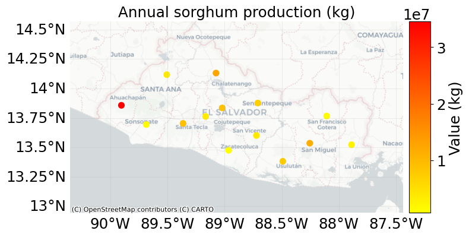

png

```python
%matplotlib inline
import contextily as ctx

for exp in exposures_dict.values():
    exp.plot_basemap(
        title=exp.description,   # Title for the map. This is the default value.
        ignore_zero=False,       # Whether to plot points with zero value
        buffer=50000,            # Add a buffer around the points to show a larger map region (measured in meters)
        s=50,                    # The size of point markers on the plot
        zoom=8,                  # The detail level of the map. 6 is good for a large country. 8 is good for a state or region. 13 for a city. 15 for a municipality.
        url=ctx.providers.CartoDB.Positron,
                                 # Set a basemap using contextily – here we use CartoDB's Positron which gives a pale, monochrome basemap
                                 #     Another good option is OpenStreetMap's Mapnik (`ctx.providers.OpenStreetMap.Mapnik`)
                                 #     ... this gives a more colourful basemap
                                 #     See all options at: https://xyzservices.readthedocs.io/en/stable/gallery.html
        pop_name=False,          # Add the names of populated places to the map – often not necessary when you have a basemap
        vmax=None,               # Set the maximum value for the colour scale – use this if you want a consistent scale across multiple plots.
        cmap="autumn_r",         # Colour scheme to use for the points. See https://matplotlib.org/stable/tutorials/colors/colormaps.html for options.
        figsize=(8, 10)          # Dimensions of the output figure
    )
```

## 2.4 Visualize Exposures: choropleth

The Exposure data here is a single point per department. We can make the data easier to visualize by combining it with shapefile information for the administrative regions:

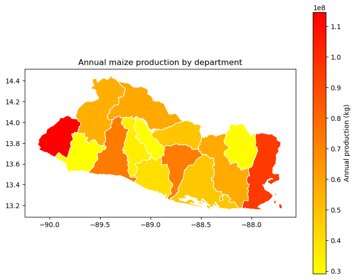

png

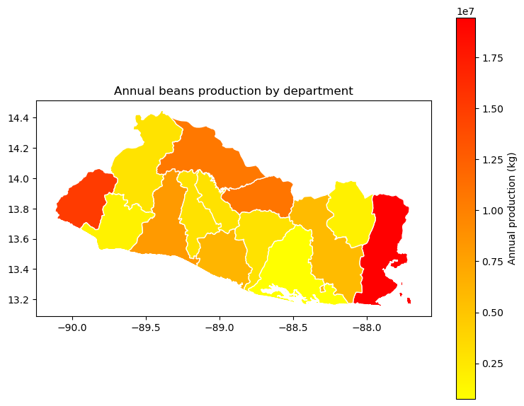

png

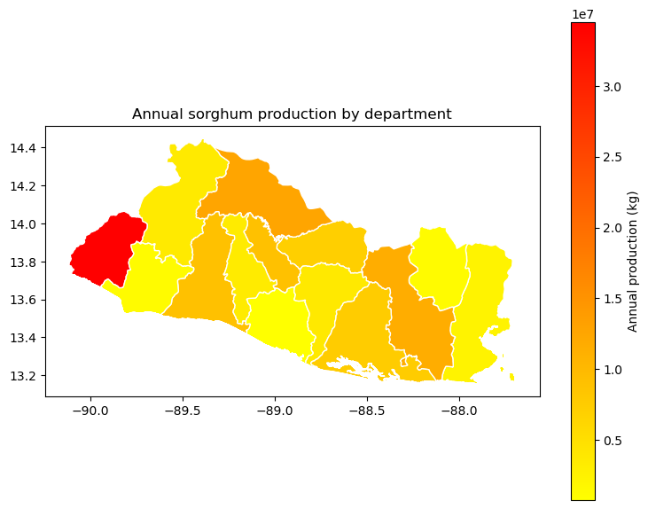

png

```python
import numpy as np
import geopandas as gpd
import cartopy.crs as ccrs
from climada.util import plot as u_plot

# Read in the shapefile to a geodataframe using geopandas
shapefile_path = "../data/SLV_departments_shapefile/SLV_ADMIN1_outlines_only.shp"
slv_gdf = gpd.read_file(shapefile_path)

for crop, exp in exposures_dict.items():
    # Spatial join using the exp geodataframe's exp.geometry column
    exp_gdf = gpd.sjoin(slv_gdf, exp.gdf, how="left", predicate="intersects")
    # Plot the shapefile using the joined 'value' column to colour the shapes
    axis = exp_gdf.plot(
        column="value",
        cmap="autumn_r",
        edgecolor="white",
        legend=True,
        figsize=(9, 7),
        missing_kwds={"color": "lightgrey", "label": "No data"})
    axis.set_title(f"Annual {crop} production by department")
    # Set colorbar title
    colorbar = axis.get_figure().get_axes()[1]
    colorbar.set_ylabel(f"Annual production ({exp.value_unit})")
```

# 3 Impact functions

In this notebook we read Entity files for El Salvador and plot (uncalibrated) Impact Functions for maize, beans and sorghum.

## 3.1 Impact functions from the Entity file

Impact functions describe the relationship between the intensity of a hazard and its effect on your chosen exposure.

They are stored in the Entity Excel workbook in the ‘impact_functions’ sheet. The sheet can specify any number of impact functions. Each function is read in and stored in an `ImpactFunc` object, which are then grouped into an `ImpactFuncSet` object and stored in the `Entity`’s `impact_funcs` attribute.

All of these classes are part of CLIMADA’s `climada.entity` package.

There are two ways to create impact functions for an analysis: from an Entity file, or programatically by constructing an `ImpactFunc` object. This notebook reads from a file. For more information on Impact Functions, see the [CLIMADA User Guide](https://climada-python.readthedocs.io/en/stable/user-guide/climada_entity_ImpactFuncSet.html).

Let’s read in the Entity files and visualize the functions:

```python
from pathlib import Path

# Set the directory where our Entity files are located
ENTITY_DIR = "../data/entity_files_uncalibrated/"
# Give a dictionary of Entity file names
ENTITY_FILES = {
    "maize": "El_Salvador_Entity_Drought_Maize.xlsx",
    "beans": "El_Salvador_Entity_Drought_Beans.xlsx",
    "sorghum": "El_Salvador_Entity_Drought_Sorghum.xlsx"
}
entity_filepaths = {crop: Path(ENTITY_DIR) / filename for crop, filename in ENTITY_FILES.items()}
```

```python
import copy
from climada.entity import Entity

# Read the Entity file and set additional metadata for the Exposures
entity_dict = {}
for crop, filepath in entity_filepaths.items():
    print(f"Reading {filepath.name}...")
    entity = Entity.from_excel(filepath)
    entity.exposures.ref_year = 2026
    entity.exposures.value_unit = "kg"
    entity.exposures.description = f"Annual {crop} production ({entity.exposures.value_unit})"
    entity_dict[crop] = copy.deepcopy(entity)
```

```
Reading El_Salvador_Entity_Drought_Maize.xlsx...
Reading El_Salvador_Entity_Drought_Beans.xlsx...
Reading El_Salvador_Entity_Drought_Sorghum.xlsx...
```

```python
HAZ_TYPE = "DR"  # This is the code we use to indicate impact functions for drought in Impact Functions

# We can then store the impact function sets in their own dict:
impf_set_dict = {crop: entity.impact_funcs for crop, entity in entity_dict.items()}

for crop, impf_set in impf_set_dict.items():
    print(f"There are {impf_set.size()} impact functions for {crop} with ID(s) {impf_set.get_ids(haz_type=HAZ_TYPE)}.")
```

```
There are 1 impact functions for maize with ID(s) [101].
There are 1 impact functions for beans with ID(s) [102].
There are 1 impact functions for sorghum with ID(s) [103].
```

png

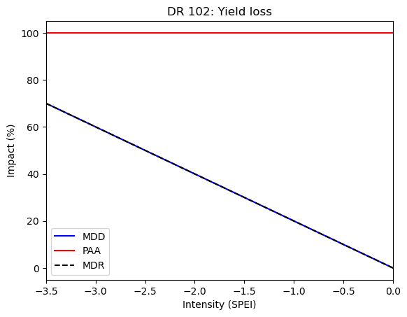

png

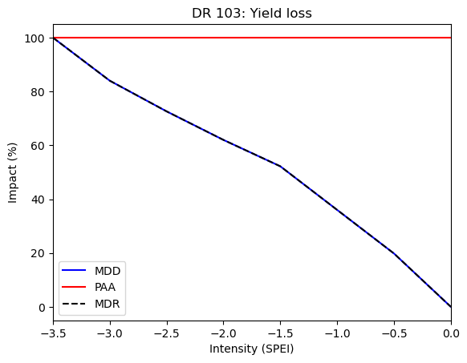

png

```python
# Visualize the impact functions
for impf_set in impf_set_dict.values():
    impf_set.plot(fun_id=None)  # Specify fun_id to plot a single function when you have several
```

An impact function is defined by the following properties:

```python
# Choose an example impact function to examine in more detail
example_impf_set = impf_set_dict["maize"]
example_fun_ids = example_impf_set.get_ids(haz_type=HAZ_TYPE)
example_impf = example_impf_set.get_func(haz_type=HAZ_TYPE,fun_id=example_fun_ids[0])

print(f"Details from an example impact function:")
# The function ID
print(f"Function ID: {example_impf.id}")
# The hazard type ('None' is acceptable)
print(f"Hazard type: {example_impf.haz_type}")
# The intensity unit
print(f"Intensity unit: {example_impf.intensity_unit}")
# The intensity values for which damage is defined
print(f"Intensity values: {example_impf.intensity}")
# The mean damage degree values: the average damage experienced by assets at these hazard intensities
print(f"Mean damage degree values: {example_impf.mdd}")
# The percentage of assets affected: the average percentage of assets affected by this intensity of hazard at a single location
print(f"Percentage of assets affected: {example_impf.paa}")
# The name (optionally)
print(f"Name: {example_impf.name}")
```

```
Details from an example impact function:
Function ID: 101
Hazard type: DR
Intensity unit: SPEI
Intensity values: [-3.5 -3.  -2.5 -2.  -1.5 -1.  -0.5  0. ]
Mean damage degree values: [1.    0.84  0.726 0.62  0.522 0.36  0.198 0.   ]
Percentage of assets affected: [1 1 1 1 1 1 1 1]
Name: Yield loss
```

# 4 Hazard

In this notebook we read in Hazards from raster files, break down their properties and plot them.

CLIMADA describes hazards as one or more (and maybe thousands) of event footprints in a file. Each event in a Hazard object is a geospatial footprint – usually an event footprint (e.g. a historical flood depth reconstruction, or a month’s simulated drought index) or a statistical summary – usually a return period footprint (e.g. the 10-year return period wind speed).

Every event has an ID and a frequency describing how often it occurs within the framework of the analysis (e.g. annual, or 1-in-100 year probability). Together these can describe a case study, a historical event set, a daily time series, a stochastic event set, or more.

Each event footprint is defined on an underlying set of Centroids – an object containing a geodataframe of points, ensuring that all hazards are defined at the same locations (events can have zero or missing values).

Centroids are often a regular grid but don’t have to be: they can be daily climate model output, or hazard interpolated to the locations of your exposures, or defined at the locations of weather stations, or on a variable resolution grid that gives more detail in more complex or more exposed areas. Usually these will be inferred from the data source, but sometimes you need to specify them.

Hazards are in the `climada.hazard` package’s `Hazard` class and Centroids in the package’s `Centroids` class.

Hazards are stored either as .hdf5 files, written and read with CLIMADA’s own format, or (when the hazard is on a regular grid) as .tif raster files or in an xarray-compatible format (e.g. NetCDF, HDF5). In the case of a .tif file you will need to provide additional metadata when you read in the file (even IDs, event frequencies, etc).

## 4.1 Hazards from raster files

Let’s read in a raster file. You can provide a single .tif with one band for each event, or a separate .tifs file for each event. In this case we use a single file with a band for each year.

In this analysis we use a different hazard file for each crop type, since each crop has a different growing season and therefore experiences a different maximum drought intensity in a given year.

```python
from climada.hazard import Hazard
from pathlib import Path

HAZARD_DIR = "../data/hazard/annual/"
HAZARD_FILES = {
    "maize": "ElSalvador_SPEI12_present_maize.tif",
    "beans": "ElSalvador_SPEI12_present_beans.tif",
    "sorghum": "ElSalvador_SPEI12_present_sorghum.tif",
}
haz_filepaths = {crop: Path(HAZARD_DIR) / filename for crop, filename in HAZARD_FILES.items()}
```

### 4.1.1 Setting event frequencies

Since we’re reading from raster files, we need to provide additional metadata that’s not contained in the .tif. This includes information on the event frequency.

The drought hazard data we use contains annual drought metrics for SPEI12 for each crop’s growing season. Therefore the frequency of each event, from a probabilistic perspective, is 1 / (number of years of data).

**Note:** This assumes that drought years are uncorrelated, which is likely not true – a more nuanced approach to drought modelling would account for this.

```python
import copy
import numpy as np
from climada.hazard import Hazard

n_years_data = 54   # 1972 to 2025 inclusive
event_frequency = 1 / n_years_data

# Read in the hazard data
haz_dict = {}

for crop, filepath in haz_filepaths.items():
    haz = Hazard.from_raster(
        files_intensity = filepath,
        band=list(np.arange(n_years_data) + 1),
        attrs={
            'unit': 'SPEI',   # as an index the SPEI has no units – so we can specify this or an empty string, as long as it is consistent with the Entity file Impact Functions
            'event_name': [str(year) for year in np.arange(1972, 2026)],     # We can optionally name the events
            'frequency': np.full(n_years_data, event_frequency)              # Define the frequency of each event
        },
        haz_type='DR',        # Specify that this is drought data
        window=None,          # Only read a window from the raster datasets, provided as a rasterio.windows.Windows object
        geometry=None,        # Only read within a given geometry, provided as a list of shapely.geometry objects
    )

    haz.intensity[haz.intensity > 0] = 0     # Set positive drought indices to zero to speed up calculation
    haz_dict[crop] = copy.deepcopy(haz)
```

```
2026-06-01 19:05:59,946 - climada.util.coordinates - INFO - Reading ../data/hazard/annual/ElSalvador_SPEI12_present_maize.tif
2026-06-01 19:05:59,971 - climada.util.coordinates - INFO - Reading ../data/hazard/annual/ElSalvador_SPEI12_present_maize.tif
2026-06-01 19:05:59,985 - climada.util.coordinates - INFO - Reading ../data/hazard/annual/ElSalvador_SPEI12_present_beans.tif
2026-06-01 19:06:00,065 - climada.util.coordinates - INFO - Reading ../data/hazard/annual/ElSalvador_SPEI12_present_beans.tif
2026-06-01 19:06:00,079 - climada.util.coordinates - INFO - Reading ../data/hazard/annual/ElSalvador_SPEI12_present_sorghum.tif
2026-06-01 19:06:00,084 - climada.util.coordinates - INFO - Reading ../data/hazard/annual/ElSalvador_SPEI12_present_sorghum.tif
```

```python
# Print some properties of the hazards
# Some of these properties are common to all hazards, so we only print them for maize

haz = haz_dict["maize"]
print("Hazard properties:")
print(f"Number of events: {haz.size}")
print(f"Number of centroids at which the hazard is defined: {haz.centroids.size}")
print(f"Hazard CRS: {haz.centroids.crs}")
print(f"Latitude range: ({haz.centroids.lat.min():.2f}, {haz.centroids.lat.max():.2f})")
print(f"Longitude range: ({haz.centroids.lon.min():.2f}, {haz.centroids.lon.max():.2f})")
print(f"Event frequencies ({haz.frequency_unit}): {haz.frequency}")
print(f"Minimum fraction: {haz.fraction.min()}")
print(f"Maximum fraction: {haz.fraction.max()}")
for crop, haz_crop in haz_dict.items():
    print(f"Minimum intensity for {crop}: {haz_crop.intensity.min()} {haz.units}")
for crop, haz_crop in haz_dict.items():
    print(f"Maximum intensity for {crop}: {haz_crop.intensity.max()} {haz.units}")
```

```
Hazard properties:
Number of events: 54
Number of centroids at which the hazard is defined: 15
Hazard CRS: GEOGCS["WGS 84",DATUM["WGS_1984",SPHEROID["WGS 84",6378137,298.257223563,AUTHORITY["EPSG","7030"]],AUTHORITY["EPSG","6326"]],PRIMEM["Greenwich",0,AUTHORITY["EPSG","8901"]],UNIT["degree",0.0174532925199433,AUTHORITY["EPSG","9122"]],AXIS["Latitude",NORTH],AXIS["Longitude",EAST],AUTHORITY["EPSG","4326"]]
Latitude range: (13.25, 14.25)
Longitude range: (-89.75, -87.75)
Event frequencies (1/year): [0.01851852 0.01851852 0.01851852 0.01851852 0.01851852 0.01851852
 0.01851852 0.01851852 0.01851852 0.01851852 0.01851852 0.01851852
 0.01851852 0.01851852 0.01851852 0.01851852 0.01851852 0.01851852
 0.01851852 0.01851852 0.01851852 0.01851852 0.01851852 0.01851852
 0.01851852 0.01851852 0.01851852 0.01851852 0.01851852 0.01851852
 0.01851852 0.01851852 0.01851852 0.01851852 0.01851852 0.01851852
 0.01851852 0.01851852 0.01851852 0.01851852 0.01851852 0.01851852
 0.01851852 0.01851852 0.01851852 0.01851852 0.01851852 0.01851852
 0.01851852 0.01851852 0.01851852 0.01851852 0.01851852 0.01851852]
Minimum fraction: 1.0
Maximum fraction: 1.0
Minimum intensity for maize: -5.831377029418945 SPEI
Minimum intensity for beans: -5.831377029418945 SPEI
Minimum intensity for sorghum: -4.955569744110107 SPEI
Maximum intensity for maize: 0.0 SPEI
Maximum intensity for beans: 0.0 SPEI
Maximum intensity for sorghum: 0.0 SPEI
```

CLIMADA calculations are more efficient when parts of the Hazard that don’t cause impacts are set to zero, because of the way it uses sparse matrices.

(This calculation is small, so it’s not very important, but we do it anyway, we setting values of the SPEI index > 0 to equal zero anyway

```python
import copy

haz_masked_dict = {}

for crop, haz in haz_dict.items():
    new_haz = copy.deepcopy(haz)
    new_haz.intensity[new_haz.intensity > 0] = 0
    haz_masked_dict[crop] = new_haz
```

**Note:** In the Starter Pack for Peru, we subset the Hazard to include only Centroids that have a hazard > 0. This is a decision following the high resolution of the hazard data. The drought data here is different, and zero-valued (and positive-valued) hazard is valuable to include, since it shows us any locations *not* affected by drought, which we want to know.

## 4.2 Plotting hazards

We can visualise hazards using methods in the `Hazard` class. This drought hazard is defined on an underlying regular grid.

When we use the `Hazard.plot_intensity` method, we can call it with the `event` parameter set to an event ID (to plot individual events) or set to zero, (to plot the highest intensity value across all events).

This ‘maximum intensity’ plot doesn’t work for SPEI, where stronger droughts have large *negative* values. The easiest way to visualize the most intense event, then, is briefly to copy the Hazard and multiply the intensity by -1, so that stronger droughts have larger positive values:

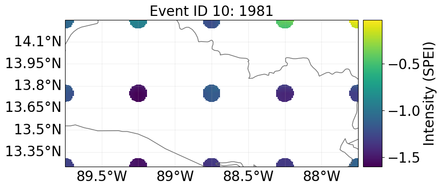

png

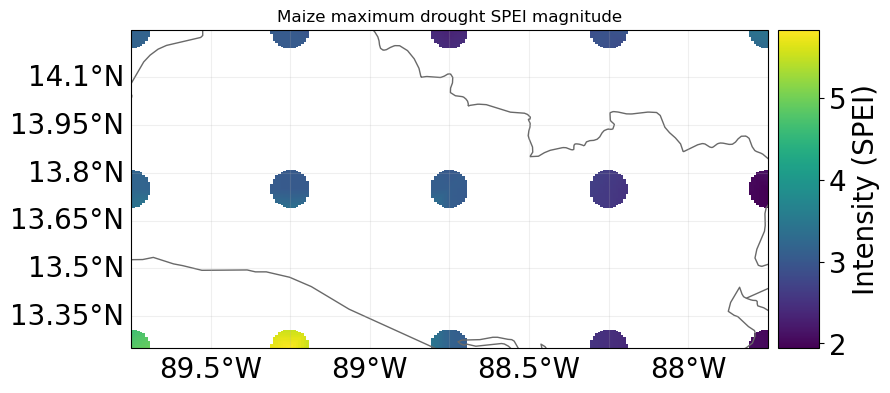

png

```python
%matplotlib inline
from matplotlib import pyplot as plt

# Plot an individual event
_ = haz_dict["maize"].plot_intensity(event=10)

haz_inverted = copy.deepcopy(haz_dict["maize"])
haz_inverted.intensity = -haz_inverted.intensity
axis = haz_inverted.plot_intensity(event=0)
_ = axis.set_title("Maize maximum drought SPEI magnitude")
```

We can also plot the hazard values at individual centroids:

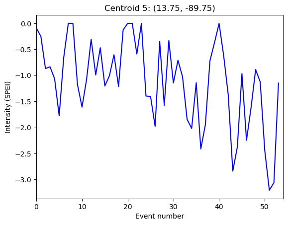

png

```python
# Plot unmasked hazard time series
_ = haz_dict["maize"].plot_intensity(centr=5)
```

## 4.3 Hazard object structure

The Hazard is defined through a few key properties: - `centroids`: a CLIMADA Centroids object, which specifies the geographic points on which the hazard’s events are all defined - `intensity`: a sparse matrix, with dimensions (number of events) x (number of centroids), specifying the intensity of the hazard for each location and each event. (A sparse matrix is an efficient way to store matrices where many entries might be zero, which is the case for many hazards, including floods) - `fraction`: another sparse matrix with the same dimensions, this time specifying the fraction of the assets affected by each event at each location. In this study we assume that all exposures are affected, so this matrix isn’t required. - `frequency`: an array giving the probabilistic frequency of each event. We defined these above

The underlying centroids can be visualized:

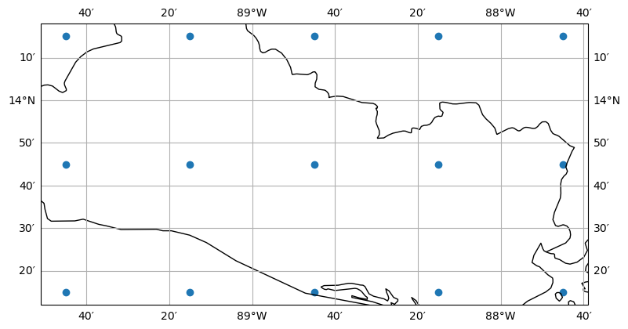

png

```python
_ = haz_dict["maize"].centroids.plot()
```

# 5 Uncalibrated risk calculations

This notebook will walk through the a risk calculation in CLIMADA with the uncalibrated data.

It will read in data, create the CLIMADA objects needed for the analysis, run the risk calculation, and explore the outputs including plots and statistics.

This analysis is being performed with the *uncalibrated* Entity files containing our first guess impact functions. Therefore the purpose of this notebook is also to notice the shortcomings of the analysis and identify how it has to be improved.

```python
from pathlib import Path

# Set up paths to data
ENTITY_DIR = "../data/entity_files_uncalibrated/"
ENTITY_FILES = {
    "maize": "El_Salvador_Entity_Drought_Maize.xlsx",
    "beans": "El_Salvador_Entity_Drought_Beans.xlsx",
    "sorghum": "El_Salvador_Entity_Drought_Sorghum.xlsx"
}
entity_filepaths = {crop: Path(ENTITY_DIR) / filename for crop, filename in ENTITY_FILES.items()}

# Set up paths to hazard data (different crops experience different hazards)
HAZARD_DIR = "../data/hazard/annual/"
HAZARD_FILES = {
    "maize": "ElSalvador_SPEI12_present_maize.tif",
    "beans": "ElSalvador_SPEI12_present_beans.tif",
    "sorghum": "ElSalvador_SPEI12_present_sorghum.tif",
}
haz_filepaths = {crop: Path(HAZARD_DIR) / filename for crop, filename in HAZARD_FILES.items()}
```

## 5.1 Read in data

### 5.1.1 Entity files

```python
import copy
from climada.entity import Entity

# Read the Entity file and set additional metadata for the Exposures
entity_dict = {}
for crop, filepath in entity_filepaths.items():
    print(f"Reading {filepath.name}...")
    entity = Entity.from_excel(filepath)
    entity.exposures.ref_year = 2023
    entity.exposures.value_unit = "kg"
    entity.exposures.description = f"Annual production: {crop} ({entity.exposures.value_unit})"
    entity_dict[crop] = copy.deepcopy(entity)
    print(f"Read Entity with {len(entity.exposures.gdf)} exposure points")
```

```
Reading El_Salvador_Entity_Drought_Maize.xlsx...
Read Entity with 14 exposure points
Reading El_Salvador_Entity_Drought_Beans.xlsx...
Read Entity with 14 exposure points
Reading El_Salvador_Entity_Drought_Sorghum.xlsx...
Read Entity with 14 exposure points
```

### 5.1.2 Plot exposures

[figure not shown]

png

[figure not shown]

png

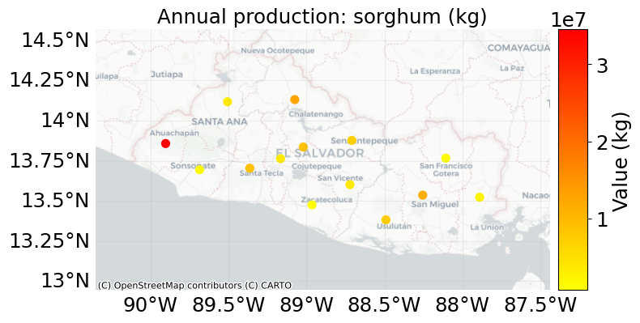

png

```python
%matplotlib inline
for crop, entity in entity_dict.items():
    entity.exposures.plot_basemap(
        title=f"Annual production: {crop} ({entity.exposures.value_unit})",
        ignore_zero=True,        # Whether to plot points with zero value
        buffer=50000,            # Add a buffer around the points to show a larger map region (measured in meters)
        s=50,                    # The size of point markers on the plot
        zoom=8,                  # The detail level of the map. 6 is good for a large country. 8 is good for a state or region. 13 for a city. 15 for a municipality.
        pop_name=False,          # Add the names of populated places to the map – often not necessary when you have a basemap
        vmax=None,               # Set the maximum value for the colour scale – use this if you want a consistent scheme across multiple plots.
        cmap="autumn_r",         # Colour scheme to use for the points. See https://matplotlib.org/stable/tutorials/colors/colormaps.html for options.
        figsize=(8, 10)          # Dimensions of the output figure
    )
```

### 5.1.3 Plot uncalibrated impact functions

png

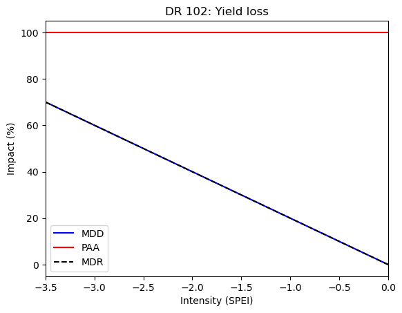

png

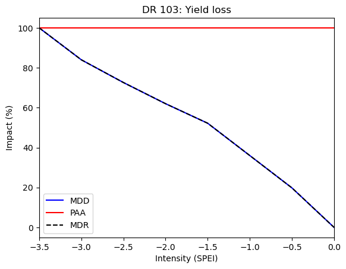

png

```python
for entity in entity_dict.values():
    entity.impact_funcs.plot()
```

### 5.1.4 Hazard

The hazard data comes from simulated SPEI data for recent decades. Note that this is note a reconstruction: while the hazard data has droughts, they will not necessarily occur in the same years as historical observations.

```python
import copy
import numpy as np
from climada.hazard import Hazard

n_years_data = 54   # 1972 to 2025 inclusive
event_frequency = 1 / n_years_data

# Read in the hazard data
haz_dict = {}

for crop, filepath in haz_filepaths.items():
    haz = Hazard.from_raster(
        files_intensity = filepath,
        band=list(np.arange(n_years_data) + 1),
        attrs={
            'unit': 'SPEI',   # as an index the SPEI has no units – so we can specify this or an empty string, as long as it is consistent with the Entity file Impact Functions
            'event_name': [str(year) for year in np.arange(1972, 2026)],     # We can optionally name the events
            'frequency': np.full(n_years_data, event_frequency)              # Define the frequency of each event
        },
        haz_type='DR',        # Specify that this is drought data
        window=None,          # Only read a window from the raster datasets, provided as a rasterio.windows.Windows object
        geometry=None,        # Only read within a given geometry, provided as a list of shapely.geometry objects
    )

    haz.intensity[haz.intensity > 0] = 0     # Set positive drought indices to zero to speed up calculation
    haz_dict[crop] = copy.deepcopy(haz)
```

```
2026-07-03 09:50:05,960 - climada.util.coordinates - INFO - Reading ../data/hazard/annual/ElSalvador_SPEI12_present_maize.tif
2026-07-03 09:50:05,974 - climada.util.coordinates - INFO - Reading ../data/hazard/annual/ElSalvador_SPEI12_present_maize.tif
2026-07-03 09:50:05,981 - climada.util.coordinates - INFO - Reading ../data/hazard/annual/ElSalvador_SPEI12_present_beans.tif
2026-07-03 09:50:05,986 - climada.util.coordinates - INFO - Reading ../data/hazard/annual/ElSalvador_SPEI12_present_beans.tif
2026-07-03 09:50:05,991 - climada.util.coordinates - INFO - Reading ../data/hazard/annual/ElSalvador_SPEI12_present_sorghum.tif
2026-07-03 09:50:05,994 - climada.util.coordinates - INFO - Reading ../data/hazard/annual/ElSalvador_SPEI12_present_sorghum.tif
```

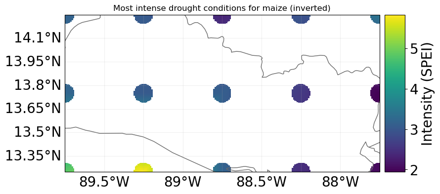

png

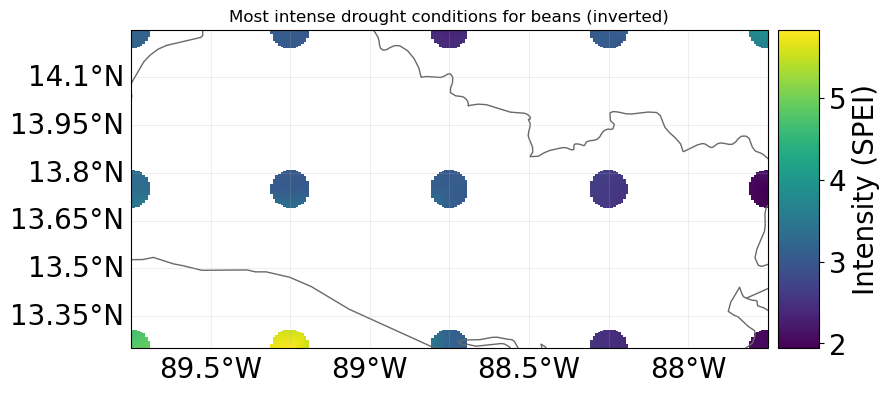

png

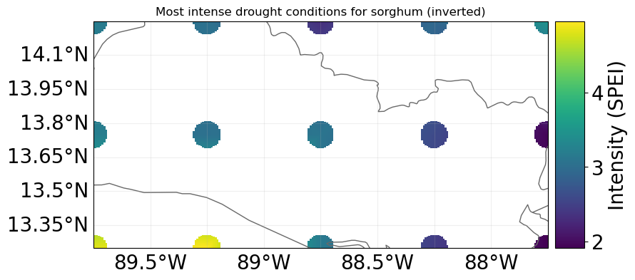

png

```python
# Plot most intense values from all events
# As in the Hazard notebook, for the plot we multiply the SPEI by -1 so that larger positive values are more intense
for crop, haz in haz_dict.items():
    haz_inverted = copy.deepcopy(haz)
    haz_inverted.intensity = -haz.intensity
    axis = haz_inverted.plot_intensity(event=0)
    _ = axis.set_title(f"Most intense drought conditions for {crop} (inverted)")
```

### 5.1.5 Map Hazard centroids to Exposure points

When CLIMADA is given a hazard and an exposure dataset it has to infer the intensity of the hazard at every exposure point. Often the hazard centroids and the exposure locations do not line up exactly. In these cases, CLIMADA finds the closest hazard centroid for each exposure, within a certain maximum search distance, set by a `threshold` parameter (or estimated by the model if not provided).

The hazard in this dataset is on a regular grid, and so CLIMADA is able to choose a distance threshold and map to the nearest centroids without difficulty.

```python
for crop in entity_dict.keys():
    ent = entity_dict[crop]
    haz = haz_dict[crop]
    ent.exposures.assign_centroids(hazard=haz, overwrite=True)
```

```
2026-07-03 09:50:09,129 - climada.entity.exposures.base - INFO - Matching 14 exposures with 15 centroids.
2026-07-03 09:50:09,138 - climada.util.coordinates - INFO - No exact centroid match found. Reprojecting coordinates to nearest neighbor closer than the threshold = 1.0 degree
2026-07-03 09:50:09,145 - climada.entity.exposures.base - INFO - Matching 14 exposures with 15 centroids.
2026-07-03 09:50:09,150 - climada.util.coordinates - INFO - No exact centroid match found. Reprojecting coordinates to nearest neighbor closer than the threshold = 1.0 degree
2026-07-03 09:50:09,157 - climada.entity.exposures.base - INFO - Matching 14 exposures with 15 centroids.
2026-07-03 09:50:09,164 - climada.util.coordinates - INFO - No exact centroid match found. Reprojecting coordinates to nearest neighbor closer than the threshold = 1.0 degree
```

## 5.2 Calculate risk

With all these ingredients we can run risk calculations using CLIMADA’s `ImpactCalc` class.

The following sections run the calculations and visualize them. The first-guess outputs have shortcomings that are discussed at the end of the notebook, and which will be used to guide the calibrations.

```python
from climada.engine import ImpactCalc, ImpactFreqCurve

impacts_dict = {}

for crop in entity_dict.keys():
    ent = entity_dict[crop]
    haz = haz_dict[crop]

    # The ImpactCalc class sets up the calculation
    imp_calc = ImpactCalc(
        exposures=ent.exposures,
        impfset=ent.impact_funcs,
        hazard=haz
    )
    # ...and its .impact method runs the calculation, creating an Impact object
    imp = imp_calc.impact(
        save_mat=True,          # Save the impact matrix (see below). This can be large, but we want it to explore some additional calculations
        assign_centroids=False  # Don't (re)assign centroids
    )
    impacts_dict[crop] = copy.deepcopy(imp)
```

[output not shown]

The Impact object has properties and methods that support you in creating risk statistics.

At the core of it is the impact matrix, which is a sparse matrix with dimensions (number of events) x (number of exposure points). It gives the calculated impact of each event at each point of exposure.

We explore this:

```python
%matplotlib inline
import matplotlib.pyplot as plt

for crop, imp in impacts_dict.items():
    print(f"\nImpacts for {crop}:")
    print(f"Number of exposures: {len(imp.eai_exp)}")
    print(f"Number of events: {len(imp.event_id)}")
    print(f"Size of impact matrix: {imp.imp_mat.shape}")

    # Summing the impact across all exposed points gives us the total impact per event. This is calculated during the impact calculation and stored in the `.at_event` attribute.
    print("Total impact per event:")
    print([f'{event_name}: {impact:,.0f}' for event_name, impact in zip(imp.event_name, imp.at_event)])

    # Combining the event-wise impacts with the events' frequencies let us calculate the average annual loss (AAL). This is stored in the `.aal_agg` attribute.
    print(f"Average annual impact/loss per event: {imp.aai_agg:.0f}")
```

```
Impacts for maize:
Number of exposures: 14
Number of events: 54
Size of impact matrix: (54, 14)
Total impact per event:
['1972: 79,283,075', '1973: 135,194,513', '1974: 162,450,732', '1975: 222,956,856', '1976: 321,380,924', '1977: 352,664,421', '1978: 202,887,747', '1979: 2,665,584', '1980: 28,137,507', '1981: 353,461,779', '1982: 103,830,466', '1983: 106,358,951', '1984: 17,332,197', '1985: 212,567,888', '1986: 256,824,801', '1987: 390,571,962', '1988: 249,073,617', '1989: 157,652,993', '1990: 274,898,970', '1991: 82,827,127', '1992: 0', '1993: 0', '1994: 32,617,210', '1995: 5,324,946', '1996: 348,277,465', '1997: 366,973,191', '1998: 474,528,996', '1999: 97,383,204', '2000: 421,609,073', '2001: 72,434,805', '2002: 325,517,947', '2003: 451,887,691', '2004: 213,813,516', '2005: 408,090,693', '2006: 404,691,706', '2007: 424,441,132', '2008: 443,865,510', '2009: 280,339,863', '2010: 182,677,184', '2011: 320,007,835', '2012: 203,779,451', '2013: 283,243,235', '2014: 444,117,637', '2015: 452,868,276', '2016: 435,741,562', '2017: 245,122,907', '2018: 377,308,328', '2019: 432,177,757', '2020: 401,166,393', '2021: 414,319,123', '2022: 506,728,354', '2023: 496,219,270', '2024: 639,591,982', '2025: 349,994,082']
Average annual impact/loss per event: 271664490

Impacts for beans:
Number of exposures: 14
Number of events: 54
Size of impact matrix: (54, 14)
Total impact per event:
['1972: 10,579,714', '1973: 0', '1974: 11,103,340', '1975: 4,129,093', '1976: 19,596,878', '1977: 23,572,907', '1978: 19,420,591', '1979: 191,512', '1980: 392,434', '1981: 21,299,299', '1982: 3,635,761', '1983: 8,077,999', '1984: 1,109,034', '1985: 13,191,165', '1986: 0', '1987: 26,068,790', '1988: 17,579,719', '1989: 0', '1990: 17,897,289', '1991: 0', '1992: 2,007,790', '1993: 0', '1994: 1,986,619', '1995: 135,315', '1996: 0', '1997: 25,721,100', '1998: 35,573,866', '1999: 190,138', '2000: 25,797,639', '2001: 18,453,498', '2002: 21,998,679', '2003: 13,429,990', '2004: 21,406,715', '2005: 7,753,979', '2006: 29,827,131', '2007: 30,314,781', '2008: 32,119,209', '2009: 24,664,775', '2010: 4,278,709', '2011: 22,134,249', '2012: 13,783,186', '2013: 618,879', '2014: 31,104,147', '2015: 32,629,175', '2016: 33,853,048', '2017: 11,900,064', '2018: 25,753,254', '2019: 32,096,280', '2020: 23,879,236', '2021: 29,287,715', '2022: 38,393,967', '2023: 42,296,866', '2024: 52,227,035', '2025: 8,491,564']
Average annual impact/loss per event: 16517669

Impacts for sorghum:
Number of exposures: 14
Number of events: 54
Size of impact matrix: (54, 14)
Total impact per event:
['1972: 1,894,654', '1973: 16,044,979', '1974: 24,188,820', '1975: 31,342,027', '1976: 37,432,153', '1977: 49,265,128', '1978: 19,080,761', '1979: 212,848', '1980: 3,166,955', '1981: 48,490,082', '1982: 23,020,197', '1983: 20,322,540', '1984: 4,326,022', '1985: 29,023,709', '1986: 31,332,423', '1987: 50,465,984', '1988: 6,166,782', '1989: 20,107,889', '1990: 37,418,525', '1991: 12,344,531', '1992: 0', '1993: 0', '1994: 1,704,506', '1995: 340,076', '1996: 48,374,383', '1997: 51,161,334', '1998: 50,269,976', '1999: 14,038,068', '2000: 58,220,074', '2001: 6,849,590', '2002: 37,550,110', '2003: 57,434,663', '2004: 32,530,769', '2005: 57,628,280', '2006: 58,885,301', '2007: 55,463,895', '2008: 65,382,305', '2009: 43,809,657', '2010: 23,562,714', '2011: 32,470,647', '2012: 22,411,538', '2013: 36,963,028', '2014: 59,406,032', '2015: 66,933,682', '2016: 63,375,284', '2017: 33,444,241', '2018: 54,027,541', '2019: 57,326,546', '2020: 51,497,828', '2021: 54,541,801', '2022: 71,607,720', '2023: 73,244,501', '2024: 84,285,371', '2025: 49,073,846']
Average annual impact/loss per event: 35915969
```

## 5.3 Plot simulated losses and exceedance

We can plot the losses simulated for each year

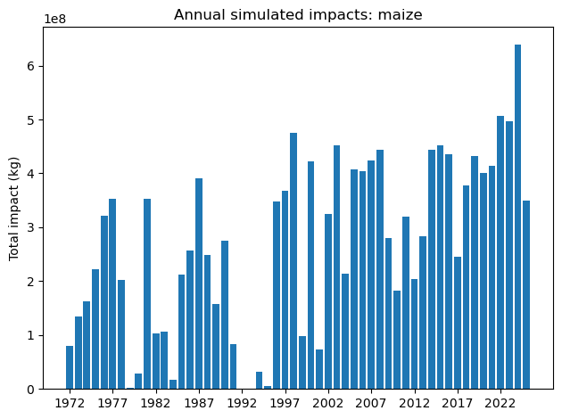

png

[figure not shown]

png

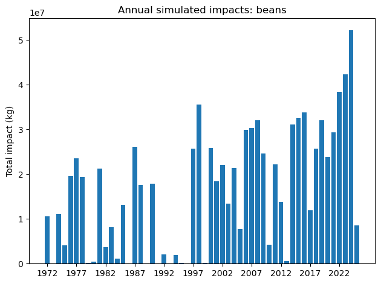

png

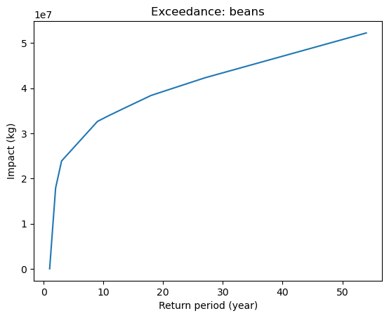

png

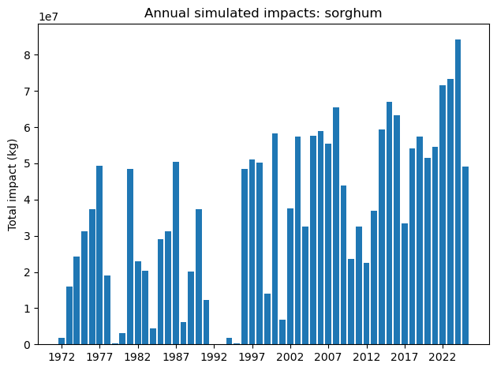

png

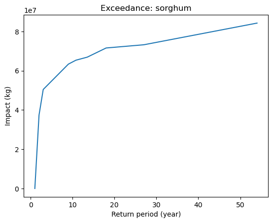

png

```python
for crop, imp in impacts_dict.items():

    # Plot array of event losses as a bar chart
    plt.bar(imp.event_name, imp.at_event)
    plt.ylabel(f"Total impact ({imp.unit})")
    plt.title(f"Annual simulated impacts: {crop}")
    plt.xticks(ticks=range(0, len(imp.event_name), 5))
    plt.tight_layout()
    plt.show()

    # We can extract an exceedance curve, showing how total losses change with return periods
    # This method returns a ImpactFreqCurve object, which can be plotted.
    exceedance_curve = imp.calc_freq_curve(return_per=[1, 2, 3, 54/6, 54/5, 54/4, 54/3, 54/2, 54])   # Specify the return periods we want to see
    axis = exceedance_curve.plot()
    axis.set_title(f"Exceedance: {crop}")
    plt.show()
```

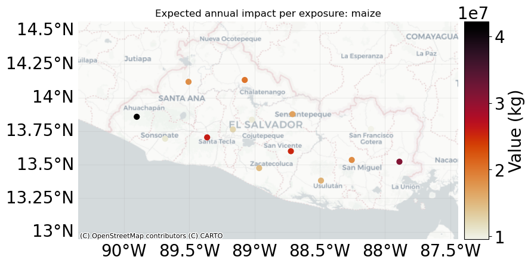

png

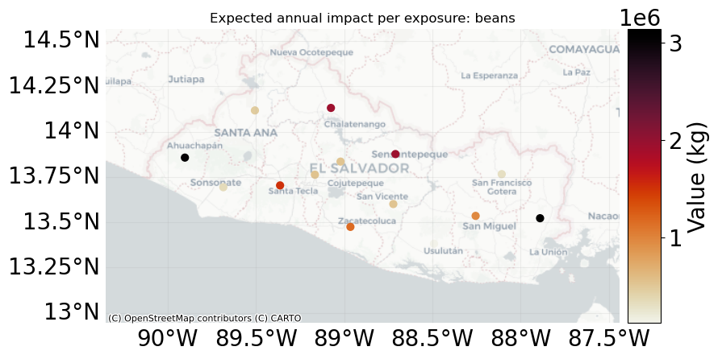

png

[figure not shown]

png

```python
import contextily as ctx

# We can map the average annual impact by individual exposure point:
for crop, imp in impacts_dict.items():
    axis = imp.plot_basemap_eai_exposure(
        ignore_zero=True,                   # Don't plot locations with zero impacts
        pop_name=False,                     # Don't plot place names
        buffer=50000,                       # Add spatial buffers to the map (in the CRS coordinate units)
        s=40,                               # The size of point markers on the plot
        zoom=8,                             # Level of detail to add to the basemap
        url=ctx.providers.CartoDB.Positron  # Basemap provider
    )
    axis.set_title(f"Expected annual impact per exposure: {crop}")
```

```python
from IPython.display import display

# Looking at the impact data across all events gives us the information about the impact per exposed point instead.
# Here we look at the results for maize
imp = impacts_dict["maize"]   # Change this to look at the other crops

# Generate a GeoDataFrame of custom return period impacts for every exposure:
custom_return_periods = [10, 20, 50]
local_exceedance, _, _ = imp.local_exceedance_impact(
    return_periods=custom_return_periods,
    method="interpolate",    # How to deal with interpolated and extrapolated impacts (default here is only interpolate)
    min_impact=0,            # Filter impacts below this value
    log_frequency=True,
    log_impact=True,
)
local_exceedance = local_exceedance.dropna()

print("Exposure level return period exceedance:")
display(local_exceedance.head())

# Plot impacts at custom return periods
axis, _ = imp.plot_rp_imp(
    return_periods=custom_return_periods,
    log10_scale=False,
    figsize=(10, 6),
    kwargs_local_exceedance_impact=None,
)
```

```
2026-07-03 09:50:12,588 - climada.engine.impact - INFO - Computing exceedance impact map for return periods: [10, 20, 50]
Exposure level return period exceedance:
```

|  | geometry | 10 | 20 | 50 |
| --- | --- | --- | --- | --- |
| 0 | POINT (-89.90196 13.85751) | 8.067158e+07 | 9.368764e+07 | 1.031985e+08 |
| 1 | POINT (-88.70886 13.87704) | 2.906687e+07 | 2.957569e+07 | 4.055981e+07 |
| 2 | POINT (-89.07457 14.13120) | 3.751947e+07 | 4.120625e+07 | 4.889992e+07 |
| 3 | POINT (-89.01998 13.83557) | 1.849256e+07 | 2.015595e+07 | 2.446105e+07 |
| 4 | POINT (-89.36268 13.70412) | 4.594824e+07 | 5.008127e+07 | 6.077808e+07 |

```
2026-07-03 09:50:12,617 - climada.engine.impact - INFO - Some errors in the previous calculation of local exceedance impacts have been corrected, see Impact.local_exceedance_impact. To reproduce data with the previous calculation, use CLIMADA v5.0.0 or less.
2026-07-03 09:50:12,618 - climada.engine.impact - INFO - Computing exceedance impact map for return periods: [10, 20, 50]
```

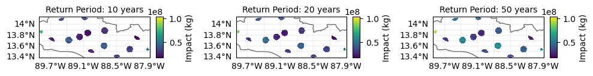

png

### 5.3.1 Discussion

We can observe a few things from these uncalibrated losses that can guide the calibration.

- From the bar chart showing year-by-year losses it’s clear that these annual impacts are too high: the default impact functions are creating significant losses *almost every year*, whereas we want to capture losses from more extreme droughts. We will probably need to adjust the impact curves so that losses at small SPEI values are not as high.
- As a consequence of this the return-period curves have large values at very low return periods: i.e. there are significant losses every one or two years. We probably want to calibrate to keep losses below 5-10 year return periods low, which is more in line with historical droughts.
- The last plot, showing point losses at different return periods, all look very similar, again because the 10-year losses are already large. We will want to calibrate so that there are more extreme events, i.e. to create a more noticeable difference between 10-year and 50-year losses.

# 6 Observations

We have historic time series for the three crops in the study – maize, beans and sorghum. For 1999-2022 we have official data from El Salvador, and for 1961-2023 we have FAO data. The data gives the production (total weight grown), area cultivated and yield (production per hectare) for each crop for the country.

We choose to work with production in this analysis. While yield is perhaps a more intuitive measure of the impact of droughts, production has the advantage that we can sum it across different departments when we run risk calculations later.

To work with production observations, however, we will need to scale the historic production to match today’s cultivated areas so that they are comparable.

This notebook reads in historic data, visualizes them, harmonizes them, and then calculates production anomalies, which will be used in the calibration.

```python
from pathlib import Path

# -----------------------------------------------
# Set up paths to data
# -----------------------------------------------

OBSERVATIONS_DIR = "../data/observations/"
OBSERVATIONS_FILES = {
    "maize": "observations_raw_maize.csv",
    "beans": "observations_raw_beans.csv",
    "sorghum": "observations_raw_sorghum.csv"
}
observations_filepaths = {
    crop: Path(OBSERVATIONS_DIR) / filename for crop, filename in OBSERVATIONS_FILES.items()
}

# How far back do we think the observations are representative?
# The more years we have, the more data we have to fit the model, but at some point the economic and agricultural
# systems become too different from the present day to be useful for calibration, especially given El Salvador's history.
# This is a subjective choice, but we can test sensitivity to this parameter by changing it and re-running the notebook.
START_YEAR = 1972
END_YEAR = 2023
```

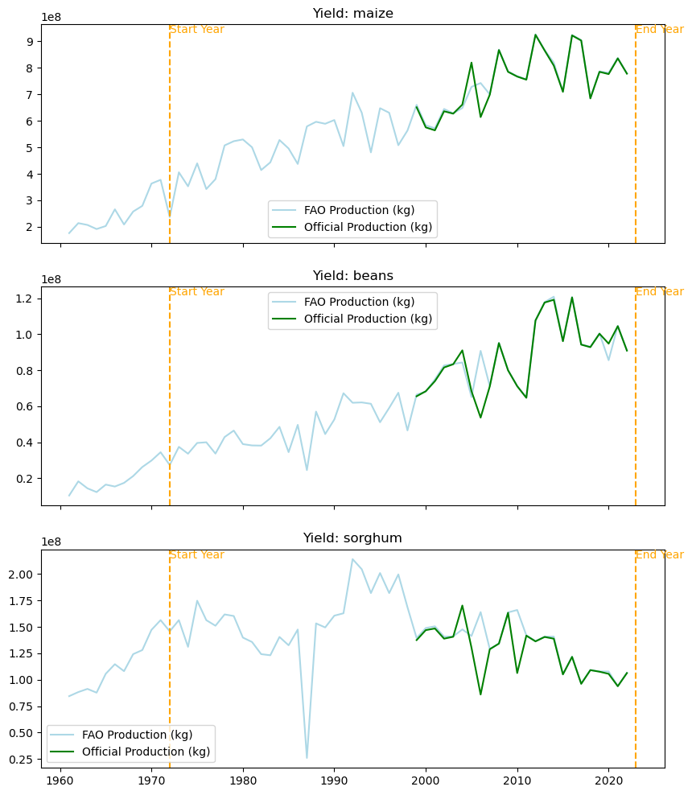

png

```python
%matplotlib inline
import pandas as pd
import numpy as np
import matplotlib.pyplot as plt
from IPython.display import display

# -----------------------------------------------
# Read and plot the raw observations
# -----------------------------------------------

obs = {crop: pd.read_csv(filepath) for crop, filepath in observations_filepaths.items()}

VARIABLE = "Production"  # Which variable are we building results from?
UNIT = "kg"
OFFICIAL_COL = f"Official {VARIABLE} ({UNIT})"
FAO_COL = f"FAO {VARIABLE} ({UNIT})"

# Plot the two time series we have for each crop:
fig, axes = plt.subplots(3, 1, figsize=(10, 12), sharex=True)
for i, (crop, obs_crop) in enumerate(obs.items()):
    axes[i].plot(obs_crop['Year'], obs_crop[FAO_COL], label=FAO_COL, color="lightblue")
    axes[i].plot(obs_crop['Year'], obs_crop[OFFICIAL_COL], label=OFFICIAL_COL, color="green")
    # add vertical lines to indicate the start and end years we are using for calibration
    axes[i].axvline(START_YEAR, color="orange", linestyle="--")
    axes[i].text(START_YEAR, axes[i].get_ylim()[1], "Start Year", color="orange", verticalalignment="top")
    axes[i].axvline(END_YEAR, color="orange", linestyle="--")
    axes[i].text(END_YEAR, axes[i].get_ylim()[1], "End Year", color="orange", verticalalignment="top")
    axes[i].set_title(f"Yield: {crop}")
    axes[i].legend()
```

While the plot time series mostly agree, there are some differences in the overlapping years. The FAO data claims to report the official country statistics and should agree. Without more in-depth research we con’t explain this: it could be due to one dataset revising statistics with more information in later years, or due to reporting periods (since crops may have more than one growing season), or some other reason.